# CSCI 385 - Second Deliverable

Brandon Weaver

11/10/2020

# Video Games Sales Analysis Part 2

# Introduction

The overall goal of this deliverable to make a prediction model that can predict the amount of sales that a video game will have based on different factors. Some examples of these factors include average critic score, the genre of the game, or the console that it was released on. I would define “success” as being able to predict a game’s sales with an error of plus or minus one million which would be a factor of one. This is because the sales figures are in the unit of millions within the data set. “Failure” would be if the average error was significantly greater than 1. Also if the models that are created have p values that are greater than 5% this would suggest that the factors that were chooses have little correlation with the games sales. This is what is referred to as the null-hypothesis. In other words, if the p value of a model is greater than 5% then we accept the null-hypothesis. While this would not be necessarily a failure, it would be disappointing.

# Expansion of the Data Set

```r
VGSales <- read_csv("Video_Games_Sales.csv")
```

I was able to expand on my original data set by pulling data off of the website rawg.io using their free to use API. To quote their about me paragraph on the website “RAWG is the largest video game database and game discovery service.” RAWG collects its data through user input on their website. This is done by having the users log their video game collection.  
My plan is to use this data to add a new variable to explore and see if it has an impact on game sales, this being the integer `playtime` which is measured in hours. My reasoning is that perhaps if a game has a high play time, then that would correlate with a better word of mouth advertising amongst gamers. This in turn would lead to more sales.  
Given the time constraint and having to learn how to make an API call in R studios. I have not had a chance to merge the two data sets together to add the `playtime` yet. However, this is one of my plans for improvement in deliverable 3.

```r
baseurl <- "https://api.rawg.io/api/games?key=5e133e1135f541f395101593d7cad2b8&page_size=40&dates=1980-01-01,2017-01-01&ordering=metacritic"
pages <- list()
for(i in 1:10){
  mydata <- fromJSON(paste0(baseurl, "&page=", i))
  pages[[i+1]] <- mydata$results
}
RAWGDataFull <- rbind_pages(pages)
RAWGData <- RAWGDataFull %>%
  select(name, playtime)
head(RAWGData)
```

```
##                          name playtime
## 1          Grand Theft Auto V       69
## 2                    Portal 2       11
## 3    The Witcher 3: Wild Hunt       51
## 4          Tomb Raider (2013)       11
## 5 The Elder Scrolls V: Skyrim       44
## 6               Left 4 Dead 2        9
```

# Data Exploration Learned by attempts to expand the Data Set

While researching how to expand my original data set, I came across some new information about my data that I wanted to document. The first is how VGCharts, the website where the video games sales data originates from, is gathered. The sales figures are based on physical copies sold at retailers. This explains why there are no data points of games there were solely releases on mobile phone platforms.  
This is important because it does create a new bias in my research. The bias being that it gives a large advantage to games that generally sell better at retail stores rather than through online stores like Steam. This could be used to explain why genres such as Strategy games are so under represented in the data. This is a genre where games tend to be more popular on the PC platform where most of their sales come through digital stores.  
In comparison genres like Sports games which are predominately only sold on physical copies for home consoles are going to be over represented in this data set.  
The Other important note is that this digital sales data is incredibly hard to come by and generally from what I have researched not public knowledge.

# Model Version 1

For all three of the different version of the model that I created, the way that I validated my model was by splitting it up 80/20 where the first 80% of the data was used to train the model and the other 20% were used to test the model. The first model I created was a linear model where I used the `Critic_Score`, `User_Score`, and `Genre` variables in order to predict the global sales of a video game.

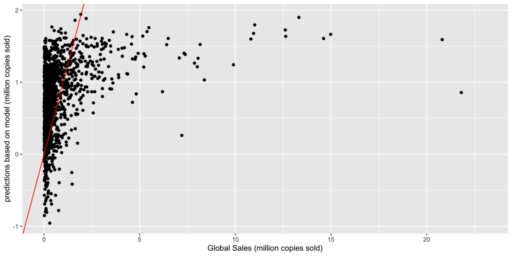

```r
train_rows <- as.vector(createDataPartition(VGSales$Global_Sales, p = 0.8, list = FALSE))

train <- VGSales[train_rows, ]
test <- VGSales[-train_rows, ]
VGmodel <- lm(Global_Sales ~ Critic_Score + User_Score + Genre, data = train)

predictions <- add_predictions(test, VGmodel)
ggplot(data = predictions, mapping = aes(x = Global_Sales, y = pred)) +
  geom_point() +
  geom_abline(intercept = 0, slope = 1, color = "red") +
  labs(x = "Global Sales (million copies sold)", y = "predictions based on model (million copies sold)")
```

```r
clean <- predictions %>%
  filter(!is.na(pred))
```

In order to get the R2(), MAE(), or RMSE() functions to work on the data set, I had to remove any predictions that were equal to NA due to there not being any `Critic_Score` values for games that are older than 2002. Perhaps, what I should do in the future is remove those values from the data set before making the model. This is similar to what I had to do for Version 3 of the model as discussed later.

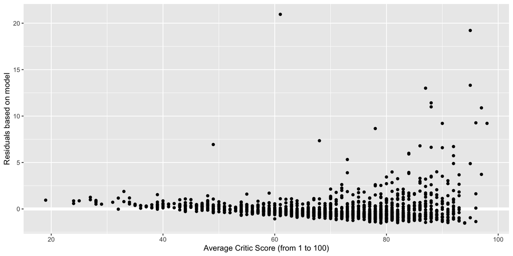

```r
resids <- add_residuals(test, VGmodel)
ggplot(data = resids, mapping = aes(x = Critic_Score, y = resid)) +
  geom_ref_line(h = 0) +
  geom_point() +
  labs(x = "Average Critic Score (from 1 to 100)", y = "Residuals based on model")
```

```r
R2(clean$pred, clean$Global_Sales)
```

```
## [1] 0.114105
```

```r
MAE(clean$pred, clean$Global_Sales)
```

```
## [1] 0.749174
```

```r
RMSE(clean$pred, clean$Global_Sales)
```

```
## [1] 1.521715
```

```r
summary(VGmodel)
```

```
##
## Call:
## lm(formula = Global_Sales ~ Critic_Score + User_Score + Genre,
##     data = train)
##
## Residuals:
##    Min     1Q Median     3Q    Max
## -1.779 -0.656 -0.293  0.174 81.597
##
## Coefficients:
##                    Estimate Std. Error t value Pr(>|t|)
## (Intercept)       -1.271929   0.154186  -8.249  < 2e-16 ***
## Critic_Score       0.037926   0.002336  16.236  < 2e-16 ***
## User_Score        -0.082140   0.022407  -3.666 0.000249 ***
## GenreAdventure    -0.363171   0.144786  -2.508 0.012158 *
## GenreFighting     -0.133653   0.123103  -1.086 0.277658
## GenreMisc          0.332624   0.122320   2.719 0.006562 **
## GenrePlatform      0.147617   0.119493   1.235 0.216748
## GenrePuzzle       -0.165391   0.198727  -0.832 0.405302
## GenreRacing        0.022862   0.103484   0.221 0.825162
## GenreRole-Playing -0.170307   0.097496  -1.747 0.080724 .
## GenreShooter       0.096385   0.091617   1.052 0.292824
## GenreSimulation   -0.151097   0.136758  -1.105 0.269271
## GenreSports       -0.020319   0.089012  -0.228 0.819442
## GenreStrategy     -0.652348   0.139219  -4.686 2.86e-06 ***
## ---
## Signif. codes:  0 '***' 0.001 '**' 0.01 '*' 0.05 '.' 0.1 ' ' 1
##
## Residual standard error: 1.952 on 5611 degrees of freedom
##   (7753 observations deleted due to missingness)
## Multiple R-squared:  0.06166,    Adjusted R-squared:  0.05949
## F-statistic: 28.36 on 13 and 5611 DF,  p-value: < 2.2e-16
```

# Model version 2

For the next model that I created, I chose to keep the same three independent variables, `Critic_Score`, `User_Score`, and `Genre`. However, this time I wanted to try to predict sales in North America. My reasoning for the switch was that the best predictor for sales was a games `Critic_Score` value and those scores came from the website Meta Critic.  
My thinking was that since Meta Critic is an English website then perhaps it would reflect better of the North American market rather than the Global market and therefore be able to make more accurate predictions.

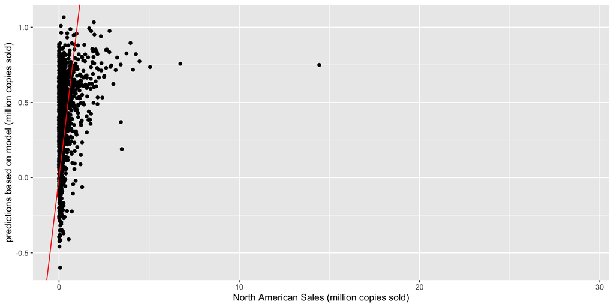

```r
train_rows <- as.vector(createDataPartition(VGSales$NA_Sales, p = 0.8, list = FALSE))

train <- VGSales[train_rows, ]
test <- VGSales[-train_rows, ]
VGmodel <- lm(NA_Sales ~ Critic_Score + User_Score + Genre, data = train)

predictions <- predict(VGmodel, test)
predictions <- add_predictions(test, VGmodel)

ggplot(data = predictions, mapping = aes(x = NA_Sales, y = pred)) +
  geom_point() +
  geom_abline(intercept = 0, slope = 1, color = "red") +
  labs(x = "North American Sales (million copies sold)", y = "predictions based on model (million copies sold)")
```

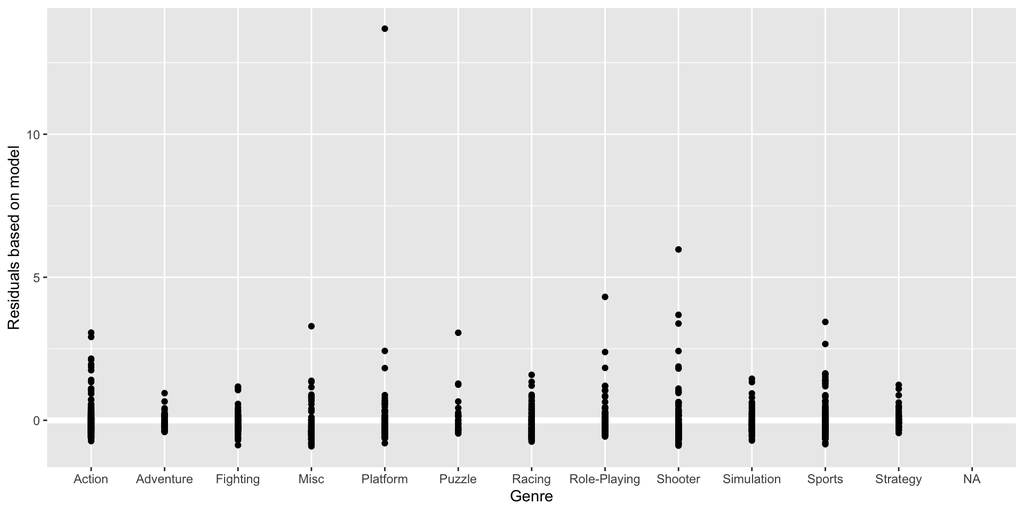

```r
resids <- add_residuals(test, VGmodel)

ggplot(data = resids, mapping = aes(x = Genre, y = resid)) +
  geom_ref_line(h = 0) +
  geom_point() +
  labs(x = "Genre", y = "Residuals based on model")
```

```r
clean <- predictions %>%
  filter(!is.na(pred))
R2(clean$pred, clean$Global_Sales)
```

```
## [1] 0.08566826
```

```r
MAE(clean$pred, clean$Global_Sales)
```

```
## [1] 0.5648172
```

```r
RMSE(clean$pred, clean$Global_Sales)
```

```
## [1] 1.369554
```

```r
summary(VGmodel)
```

```
##
## Call:
## lm(formula = NA_Sales ~ Critic_Score + User_Score + Genre, data = train)
##
## Residuals:
##    Min     1Q Median     3Q    Max
## -0.955 -0.344 -0.144  0.101 40.874
##
## Coefficients:
##                    Estimate Std. Error t value Pr(>|t|)
## (Intercept)       -0.677046   0.077336  -8.755  < 2e-16 ***
## Critic_Score       0.019798   0.001185  16.713  < 2e-16 ***
## User_Score        -0.041968   0.011322  -3.707 0.000212 ***
## GenreAdventure    -0.186381   0.071129  -2.620 0.008808 **
## GenreFighting     -0.025041   0.061142  -0.410 0.682150
## GenreMisc          0.232913   0.061295   3.800 0.000146 ***
## GenrePlatform      0.056727   0.060092   0.944 0.345214
## GenrePuzzle       -0.179618   0.102780  -1.748 0.080589 .
## GenreRacing        0.004190   0.052073   0.080 0.935870
## GenreRole-Playing -0.135454   0.048987  -2.765 0.005709 **
## GenreShooter       0.098198   0.045428   2.162 0.030689 *
## GenreSimulation   -0.095419   0.069657  -1.370 0.170788
## GenreSports       -0.006150   0.044633  -0.138 0.890411
## GenreStrategy     -0.342859   0.070017  -4.897    1e-06 ***
## ---
## Signif. codes:  0 '***' 0.001 '**' 0.01 '*' 0.05 '.' 0.1 ' ' 1
##
## Residual standard error: 0.9774 on 5612 degrees of freedom
##   (7750 observations deleted due to missingness)
## Multiple R-squared:  0.06903,    Adjusted R-squared:  0.06687
## F-statistic: 32.01 on 13 and 5612 DF,  p-value: < 2.2e-16
```

Based on the summary of this model. the R^2 value and the p-value remain similar to the first version. Also, the the Mean Absolute Error when down from 0.75 million to 0.56, which is an overall great improvement. This leads to the conclusion that my original hypothesis could be correct given the increase in accuracy.